# Pacers Player Impact Analysis

Lindsey Hornberger

2026-05-14

```r
# load libraries
library(readr)
library(ggplot2)
library(tidyr)
library(dplyr)
library(janitor)
library(zoo)
```

```r
# import data
setwd("/Users/lindseyhornberger/Desktop/My Fun Projects/nba")
nba_player_data <- read.csv("traditional.csv") # player and player_id
```

```r
# 2025 season data subset
nba_player_2025 <- nba_player_data %>% filter(season == 2025)
```

## Exploratory Data Analysis (EDA)

```
## Rows: 28,240
## Columns: 30
## $ gameid   <int> 22400061, 22400061, 22400061, 22400061, 22400061, 22400061, 2…
## $ date     <chr> "2024-10-22", "2024-10-22", "2024-10-22", "2024-10-22", "2024…
## $ type     <chr> "regular", "regular", "regular", "regular", "regular", "regul…
## $ playerid <int> 1628369, 1628401, 1627759, 201950, 1630540, 201143, 1628973, …
## $ player   <chr> "Jayson Tatum", "Derrick White", "Jaylen Brown", "Jrue Holida…
## $ team     <chr> "BOS", "BOS", "BOS", "BOS", "NYK", "BOS", "NYK", "NYK", "NYK"…
## $ home     <chr> "BOS", "BOS", "BOS", "BOS", "BOS", "BOS", "BOS", "BOS", "BOS"…
## $ away     <chr> "NYK", "NYK", "NYK", "NYK", "NYK", "NYK", "NYK", "NYK", "NYK"…
## $ MIN      <int> 30, 27, 30, 31, 26, 26, 25, 24, 21, 35, 25, 24, 24, 34, 19, 2…
## $ PTS      <int> 37, 24, 23, 18, 22, 11, 22, 12, 11, 16, 12, 4, 10, 4, 4, 3, 2…
## $ FGM      <int> 14, 8, 7, 7, 8, 4, 9, 5, 5, 7, 4, 2, 4, 1, 2, 1, 1, 0, 1, 1, …
## $ FGA      <int> 18, 13, 18, 9, 10, 7, 14, 9, 10, 13, 6, 3, 10, 7, 3, 10, 6, 0…
## $ FG.      <dbl> 77.8, 61.5, 38.9, 77.8, 80.0, 57.1, 64.3, 55.6, 50.0, 53.8, 6…
```

[output cut: 17 more lines]

```
##      gameid             date               type              playerid
##  Min.   :22400001   Length:28240       Length:28240       Min.   :   2544
##  1st Qu.:22400325   Class :character   Class :character   1st Qu.:1627936
##  Median :22400655   Mode  :character   Mode  :character   Median :1630168
##  Mean   :23816306                                         Mean   :1407570
##  3rd Qu.:22400988                                         3rd Qu.:1631131
##  Max.   :52400211                                         Max.   :1642530
##     player              team               home               away
##  Length:28240       Length:28240       Length:28240       Length:28240
##  Class :character   Class :character   Class :character   Class :character
##  Mode  :character   Mode  :character   Mode  :character   Mode  :character
##
##
##
##       MIN             PTS             FGM              FGA
##  Min.   : 0.00   Min.   : 0.00   Min.   : 0.000   Min.   : 0.000
##  1st Qu.:15.00   1st Qu.: 4.00   1st Qu.: 1.000   1st Qu.: 4.000
##  Median :24.00   Median : 9.00   Median : 3.000   Median : 7.000
##  Mean   :22.57   Mean   :10.61   Mean   : 3.881   Mean   : 8.321
##  3rd Qu.:31.00   3rd Qu.:16.00   3rd Qu.: 6.000   3rd Qu.:12.000
##  Max.   :53.00   Max.   :61.00   Max.   :22.000   Max.   :39.000
##       FG.             X3PM             X3PA             X3P.
##  Min.   :  0.0   Min.   : 0.000   Min.   : 0.000   Min.   :  0.00
##  1st Qu.: 28.6   1st Qu.: 0.000   1st Qu.: 1.000   1st Qu.:  0.00
##  Median : 44.4   Median : 1.000   Median : 3.000   Median : 25.00
##  Mean   : 42.9   Mean   : 1.259   Mean   : 3.498   Mean   : 26.59
##  3rd Qu.: 57.1   3rd Qu.: 2.000   3rd Qu.: 5.000   3rd Qu.: 50.00
##  Max.   :100.0   Max.   :12.000   Max.   :20.000   Max.   :100.00
##       FTM              FTA              FT.              OREB
##  Min.   : 0.000   Min.   : 0.000   Min.   :  0.00   Min.   : 0.000
##  1st Qu.: 0.000   1st Qu.: 0.000   1st Qu.:  0.00   1st Qu.: 0.000
##  Median : 1.000   Median : 1.000   Median : 33.30   Median : 1.000
##  Mean   : 1.589   Mean   : 2.039   Mean   : 41.63   Mean   : 1.039
##  3rd Qu.: 2.000   3rd Qu.: 3.000   3rd Qu.:100.00   3rd Qu.: 2.000
##  Max.   :21.000   Max.   :26.000   Max.   :100.00   Max.   :13.000
##       DREB             REB              AST              STL
##  Min.   : 0.000   Min.   : 0.000   Min.   : 0.000   Min.   :0.0000
##  1st Qu.: 1.000   1st Qu.: 2.000   1st Qu.: 1.000   1st Qu.:0.0000
##  Median : 2.000   Median : 3.000   Median : 2.000   Median :0.0000
##  Mean   : 3.076   Mean   : 4.115   Mean   : 2.459   Mean   :0.7653
##  3rd Qu.: 4.000   3rd Qu.: 6.000   3rd Qu.: 4.000   3rd Qu.:1.0000
##  Max.   :23.000   Max.   :28.000   Max.   :22.000   Max.   :8.0000
##       BLK               TOV              PF             X...
##  Min.   : 0.0000   Min.   : 0.00   Min.   :0.000   Min.   :-58
##  1st Qu.: 0.0000   1st Qu.: 0.00   1st Qu.:1.000   1st Qu.: -7
##  Median : 0.0000   Median : 1.00   Median :2.000   Median :  0
##  Mean   : 0.4566   Mean   : 1.26   Mean   :1.752   Mean   :  0
##  3rd Qu.: 1.0000   3rd Qu.: 2.00   3rd Qu.:3.000   3rd Qu.:  7
##  Max.   :10.0000   Max.   :11.00   Max.   :6.000   Max.   : 51
##       win             season
##  Min.   :0.0000   Min.   :2025
##  1st Qu.:0.0000   1st Qu.:2025
##  Median :1.0000   Median :2025
##  Mean   :0.5026   Mean   :2025
##  3rd Qu.:1.0000   3rd Qu.:2025
##  Max.   :1.0000   Max.   :2025
```

```
##   gameid     date     type playerid   player     team     home     away
##        0        0        0        0        0        0        0        0
##      MIN      PTS      FGM      FGA      FG.     X3PM     X3PA     X3P.
##        0        0        0        0        0        0        0        0
##      FTM      FTA      FT.     OREB     DREB      REB      AST      STL
##        0        0        0        0        0        0        0        0
##      BLK      TOV       PF     X...      win   season
##        0        0        0        0        0        0
```

## Isolate Pacers data and create metric variables

```r
pacers_2025 <- nba_player_2025 %>% filter(team == "IND") %>% clean_names()

pacers_2025 <- pacers_2025 %>%
  rename(plus_minus = x,
    fg_pct = fg,
    x3p_pct = x3p,
    ft_pct = ft
  )
pacers_2025 <- pacers_2025 %>%
  mutate(
    efg = ifelse(fga == 0, NA, (fgm + 0.5 * x3pm) / fga),
    ts = ifelse((fga + 0.44 * fta) == 0, NA, pts / (2 * (fga + 0.44 * fta))),
    pm_per_min = ifelse(min == 0, NA, plus_minus / min)
  )
```

## Create impact_score

```r
pacers_2025 <- pacers_2025 %>%
  mutate(
    efg = ifelse(fga == 0, NA, (fgm + 0.5 * x3pm) / fga),
    ts = ifelse((fga + 0.44 * fta) == 0, NA, pts / (2 * (fga + 0.44 * fta))),
    pm_per_min = ifelse(min == 0, NA, plus_minus / min)
  )

player_impact <- pacers_2025 %>%
  group_by(player) %>%
  summarise(
    games = n(),
    mpg = mean(min, na.rm = TRUE),
    ppg = mean(pts, na.rm = TRUE),
    apg = mean(ast, na.rm = TRUE),
    rpg = mean(reb, na.rm = TRUE),
    efg = mean(efg, na.rm = TRUE),
    pm_per_min = mean(pm_per_min, na.rm = TRUE)
  ) %>%
  filter(games >= 10, mpg >= 10)

player_impact
```

```
## # A tibble: 12 × 8
##    player             games   mpg   ppg   apg   rpg   efg pm_per_min
##    <chr>              <int> <dbl> <dbl> <dbl> <dbl> <dbl>      <dbl>
##  1 Aaron Nesmith         68  26.1 12.2  1.18   4.53 0.596     0.150
##  2 Andrew Nembhard       88  30.1 10.7  4.92   3.30 0.532     0.0806
##  3 Ben Sheppard          84  18.1  4.75 1.11   2.57 0.545    -0.116
##  4 Bennedict Mathurin    94  26.9 14.9  1.65   4.85 0.507    -0.0165
##  5 Jarace Walker         87  15.0  5.71 1.36   2.87 0.563    -0.232
##  6 Myles Turner          95  30.0 15.1  1.51   6.12 0.575     0.0592
##  7 Obi Toppin           102  19.5 10.3  1.55   3.98 0.593    -0.0588
##  8 Pascal Siakam        101  32.9 20.3  3.38   6.79 0.568     0.124
##  9 Quenton Jackson       28  13.6  5.79 1.89   1.57 0.469    -0.230
## 10 T.J. McConnell       102  17.8  9.20 4.35   2.63 0.530    -0.0855
## 11 Thomas Bryant         76  13.4  5.79 0.697  3.24 0.552    -0.190
## 12 Tyrese Haliburton     96  33.6 18.3  9.06   3.97 0.551     0.0975
```

```r
safe_scale <- function(x) {
  if (sd(x, na.rm = TRUE) == 0) return(rep(0, length(x)))
  (x - mean(x, na.rm = TRUE)) / sd(x, na.rm = TRUE)
}

player_impact <- player_impact %>%
  mutate(
    impact_score =
      safe_scale(ppg) * 0.25 +
      safe_scale(apg) * 0.20 +
      safe_scale(rpg) * 0.15 +
      safe_scale(efg) * 0.15 +
      safe_scale(pm_per_min) * 0.25
  ) %>%
  arrange(desc(impact_score))

player_impact
```

```
## # A tibble: 12 × 9
##    player            games   mpg   ppg   apg   rpg   efg pm_per_min impact_score
##    <chr>             <int> <dbl> <dbl> <dbl> <dbl> <dbl>      <dbl>        <dbl>
##  1 Pascal Siakam       101  32.9 20.3  3.38   6.79 0.568     0.124        1.16
##  2 Tyrese Haliburton    96  33.6 18.3  9.06   3.97 0.551     0.0975       1.13
##  3 Myles Turner         95  30.0 15.1  1.51   6.12 0.575     0.0592       0.597
##  4 Aaron Nesmith        68  26.1 12.2  1.18   4.53 0.596     0.150        0.526
##  5 Andrew Nembhard      88  30.1 10.7  4.92   3.30 0.532     0.0806       0.247
##  6 Bennedict Mathur…    94  26.9 14.9  1.65   4.85 0.507    -0.0165       0.0501
##  7 Obi Toppin          102  19.5 10.3  1.55   3.98 0.593    -0.0588       0.0162
##  8 T.J. McConnell      102  17.8  9.20 4.35   2.63 0.530    -0.0855      -0.247
##  9 Ben Sheppard         84  18.1  4.75 1.11   2.57 0.545    -0.116       -0.727
## 10 Thomas Bryant        76  13.4  5.79 0.697  3.24 0.552    -0.190       -0.751
## 11 Jarace Walker        87  15.0  5.71 1.36   2.87 0.563    -0.232       -0.765
## 12 Quenton Jackson      28  13.6  5.79 1.89   1.57 0.469    -0.230       -1.23
```

## Visualize impact_score with ggplot

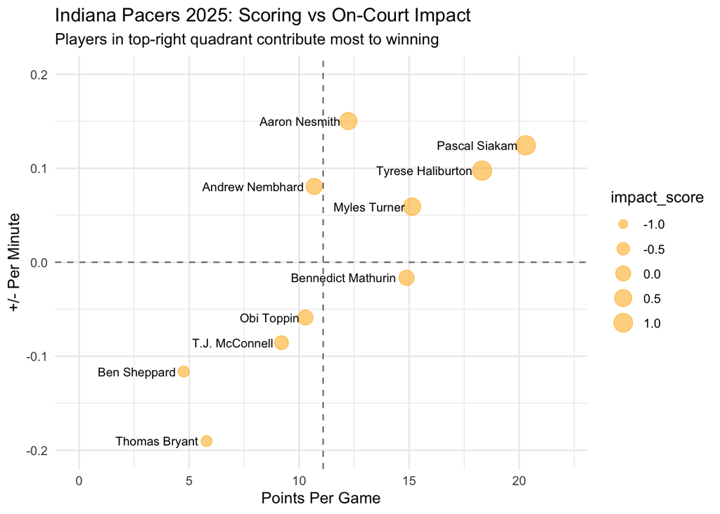

```r
ggplot(player_impact, aes(x = ppg, y = pm_per_min)) +
geom_point(aes(size = impact_score), color = "#FDBB30", alpha = 0.6) +
 geom_text(aes(label = player), hjust = 1.1, size = 3) +
  geom_hline(yintercept = 0, linetype = "dashed", color = "gray50") +
  geom_vline(xintercept = mean(player_impact$ppg),
             linetype = "dashed", color = "gray50") +
  labs(
    title = "Indiana Pacers 2025: Scoring vs On-Court Impact",
    subtitle = "Players in top-right quadrant contribute most to winning",
    x = "Points Per Game",
    y = "+/- Per Minute" ) +
    coord_cartesian(xlim = c(0, 22), ylim = c(-0.2, 0.2)
  ) +
  theme_minimal()
```

## Summary of findings

These results summarize each player’s performance using key variables—games (total appearances), **mpg** (minutes per game, indicating role and usage), **ppg**, **apg**, and **rpg** (core production stats), **efg** (shooting efficiency that accounts for three-point value), and **pm_per_min** (plus-minus scaled by playing time to estimate on-court impact). The **impact_score** combines these elements into a single metric that reflects how effectively a player contributes to team success per minute, balancing volume, efficiency, and overall influence.

**Pascal Siakam** and **Tyrese Haliburton** stand out with the highest impact scores (1.16 and 1.13 respectively), driven by strong scoring, playmaking, and positive per-minute impact, indicating they are the primary engines of team performance. Players like Myles Turner and Aaron Nesmith also show solid positive contributions with higher impact scores (0.597 and 0.526 respectively), while mid-tier players provide moderate value in more specialized or inconsistent roles. Lower or negative impact scores suggest that, despite some individual production, those players have less favorable overall on-court impact, which is common for bench or developmental players with smaller roles or lower efficiency.

© Lindsey Hornberger 2026